# Proyecto 02

Lizbeth Contreras

## Introducción

A continuación se realizará el análisis de los alumnos del Posgrado de Economía de la UNAM, Sede Facultad de Economía.

La información comprende el periodo 2006-2015, durante estos años el Posgrado ha pasado por más de 5 administraciones y por tanto la forma en la cual se ha llevado el control sobre la información de los alumnos es totalmente variada.

En la Reunión de Comité Académico celebrada en el mes de Febrero se le solicitó al Posgrado que entregara la siguiente información para los alumnos de maestría y doctorado: * Número de alumnos por generación * Número de alumnos por plan de estudios * Alumnos que han ingresado a más de un plan de estudios * Número de alumnos titulados por año * Mes en el que más se titulan

## Limpieza de los datos

Debido a no se cuenta con una metodología para la captura de datos y a que la información se encontraba en varios archivos y formatos la única forma de ligar los archivos fue mediante el número de cuenta del alumno.

### Creación de tablas

```
CREATE TABLE alumnos(
    cuenta TINYINT,
    apellido_paterno VARCHAR (12),
    apellido_materno VARCHAR (12),
    nombre VARCHAR (20),
);
```

```
CREATE TABLE posgrado(
    cuenta TINYINT,
    anio TINYINT,
    semestre TINYINT,
    programa TINYINT,
    plan TINYINT,
    ingreso_plan TINYIN,
    tutor VARCHAR (40),
    egreso TINYIN,
    fecha_grado DATE
);
```

```
CREATE TABLE programa(
    programa TINYINT,
    nom_prog VARCHAR (25),
);
```

```
CREATE TABLE plan_est(
    plan TINYINT,
    nom_plan VARCHAR (25),
);
```

## Análisis de la información

### Número de alumnos por plan

```
SELECT plan, cuenta
FROM (plan_est inner join posgrado
ON plan_est.plan=posgrado.plan)
;
```

La consulta se guarda como plan.csv

```
cat plan.csv | cut -d$'\t' -f2 | |  sort | uniq -c
```

** Maestría en Economía**

```
##   Plan Frecuencia
## 1  461          2
## 2  462          2
## 3 4040        287
## 4 4100        251
```

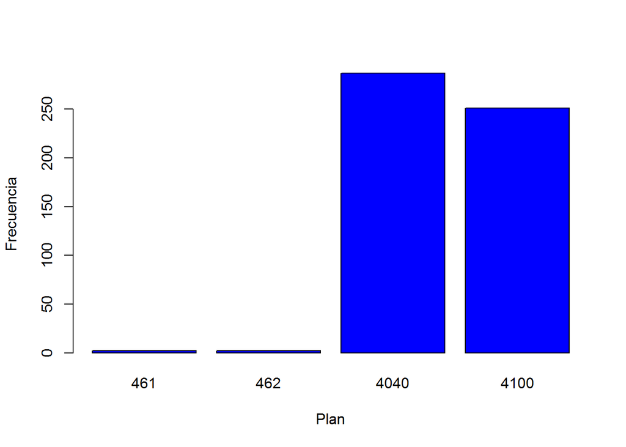

** Doctorado en Economía**

```
##   Plan Frecuencia
## 1  581          6
## 2 5040        230
## 3 5100         75
## 4 5123        159
```

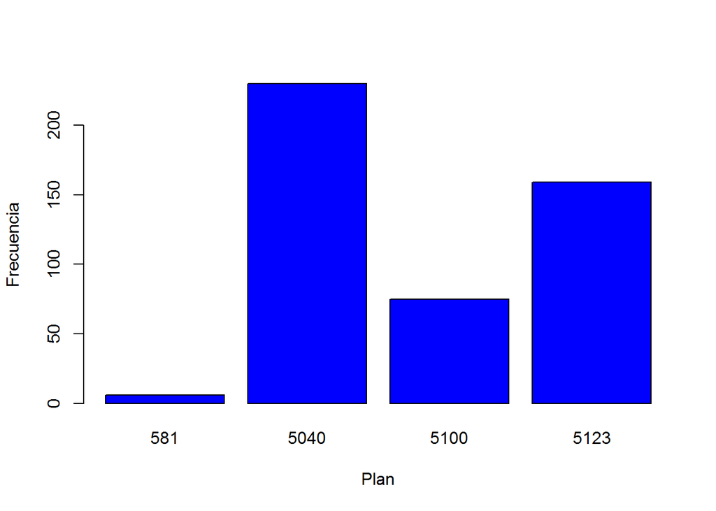

### Número de alumnos por generación

Se cuenta con un registro de 8 planes de estudio de los cuales 4 son de maestria y 4 de doctorado

#### Plan 461. Maestría en Economía

```
SELECT plan, ingreso_plan, cuenta
FROM (plan_est inner join posgrado
ON plan_est.plan=posgrado.plan)
WHERE (plan_est.plan='461'
;
```

La consulta se guarda como plan461.csv

```
cat plan461.csv | cut -d$'\t' -f2 | |  sort | uniq -c
```

```
##   Generación Frecuencia
## 1     2012-2          1
## 2     2014-1          1
```

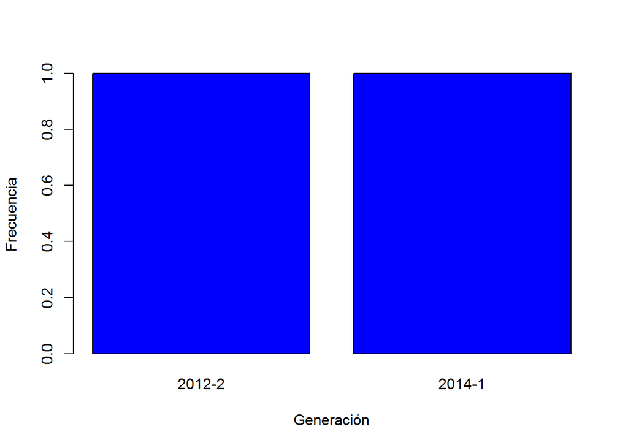

#### Plan 462. Maestría en Economía

```
SELECT plan, ingreso_plan, cuenta
FROM (plan_est inner join posgrado
ON plan_est.plan=posgrado.plan)
WHERE (plan_est.plan='462'
;
```

La consulta se guarda como plan462.csv

```
cat plan462.csv | cut -d$'\t' -f2 | |  sort | uniq -c
```

```
##   Generación Frecuencia
## 1     2009-1          1
## 2     2015-1          1
```

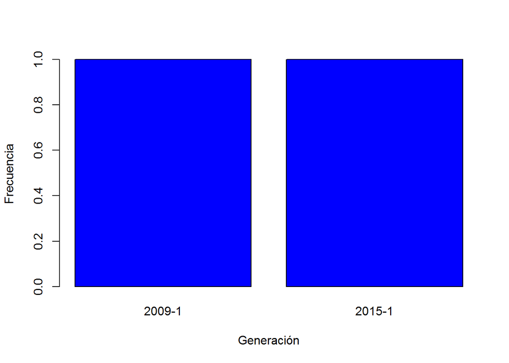

#### Plan 4040. Maestría en Economía

```
SELECT plan, ingreso_plan, cuenta
FROM (plan_est inner join posgrado
ON plan_est.plan=posgrado.plan)
WHERE (plan_est.plan='4040'
;
```

La consulta se guarda como plan4040.csv

```
cat plan4040.csv | cut -d$'\t' -f2 | |  sort | uniq -c
```

```
##   Generación Frecuencia
## 1     2005-2         37
## 2     2006-1         28
## 3     2007-1         28
## 4     2008-1         80
## 5     2009-1         46
## 6     2010-1         33
## 7     2011-1         35
```

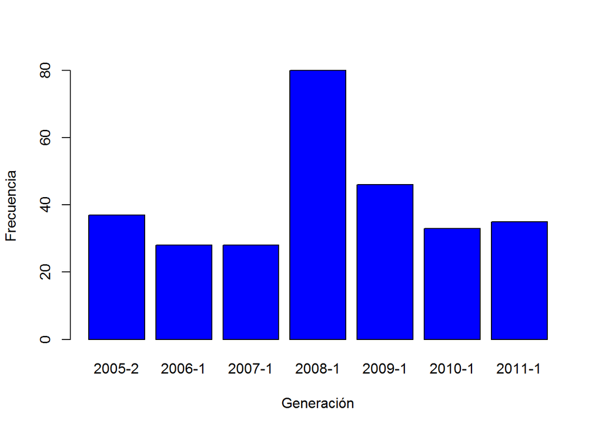

#### Plan 4100. Maestría en Economía

```
SELECT plan, ingreso_plan, cuenta
FROM (plan_est inner join posgrado
ON plan_est.plan=posgrado.plan)
WHERE (plan_est.plan='4100'
;
```

La consulta se guarda como plan4100.csv

```
cat plan4100.csv | cut -d$'\t' -f2 | |  sort | uniq -c
```

```
##   Generación Frecuencia
## 1     2011-2         64
## 2     2012-1         35
## 3     2013-1         48
## 4     2014-1         56
## 5     2015-1         48
```

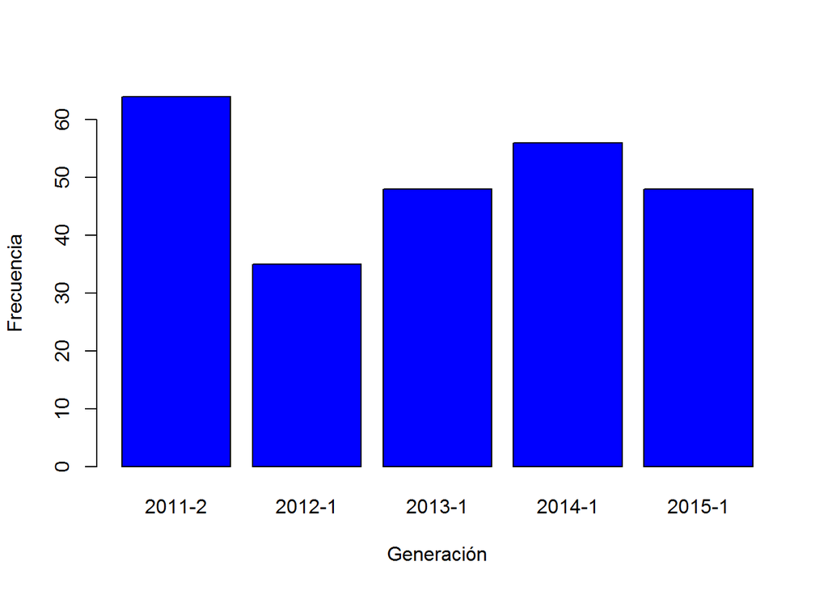

#### Plan 581. Doctorado en Economía

```
SELECT plan, ingreso_plan, cuenta
FROM (plan_est inner join posgrado
ON plan_est.plan=posgrado.plan)
WHERE (plan_est.plan='581'
;
```

La consulta se guarda como plan581.csv

```
cat plan581.csv | cut -d$'\t' -f2 | |  sort | uniq -c
```

```
##   Generación Frecuencia
## 1     2007-2          1
## 2     2008-2          1
## 3     2010-1          1
## 4     2012-2          1
## 5     2014-1          2
```

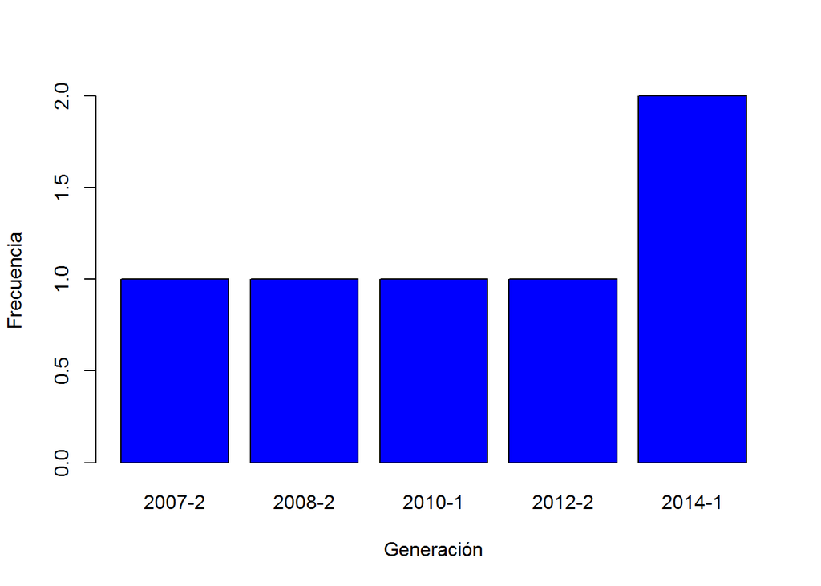

#### Plan 5040. Doctorado en Economía

```
SELECT plan, ingreso_plan, cuenta
FROM (plan_est inner join posgrado
ON plan_est.plan=posgrado.plan)
WHERE (plan_est.plan='5040'
;
```

La consulta se guarda como plan5040.csv

```
cat plan5040.csv | cut -d$'\t' -f2 | |  sort | uniq -c
```

```
##    Generación Frecuencia
## 1      2005-2         51
## 2      2006-1         18
## 3      2006-2          6
## 4      2007-1         23
## 5      2007-2         15
## 6      2008-1         13
## 7      2008-2         10
## 8      2009-1         21
## 9      2009-2         19
## 10     2010-1         32
## 11     2010-2         22
```

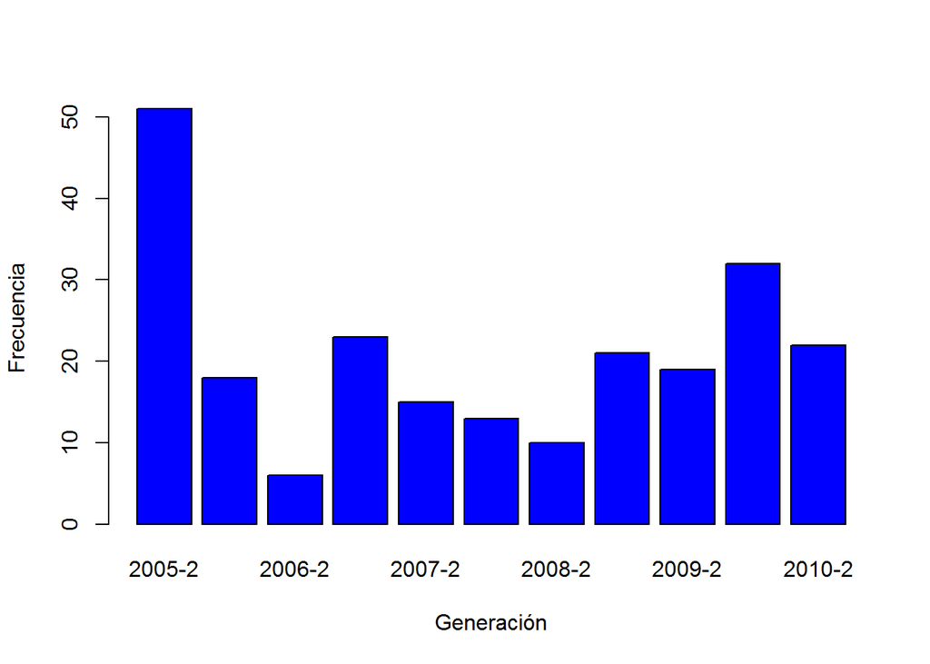

#### Plan 5100. Doctorado en Economía

```
SELECT plan, ingreso_plan, cuenta
FROM (plan_est inner join posgrado
ON plan_est.plan=posgrado.plan)
WHERE (plan_est.plan='5100'
;
```

La consulta se guarda como plan5040.csv

```
cat plan5100.csv | cut -d$'\t' -f2 | |  sort | uniq -c
```

```
##   Generación Frecuencia
## 1     2011-2         75
```

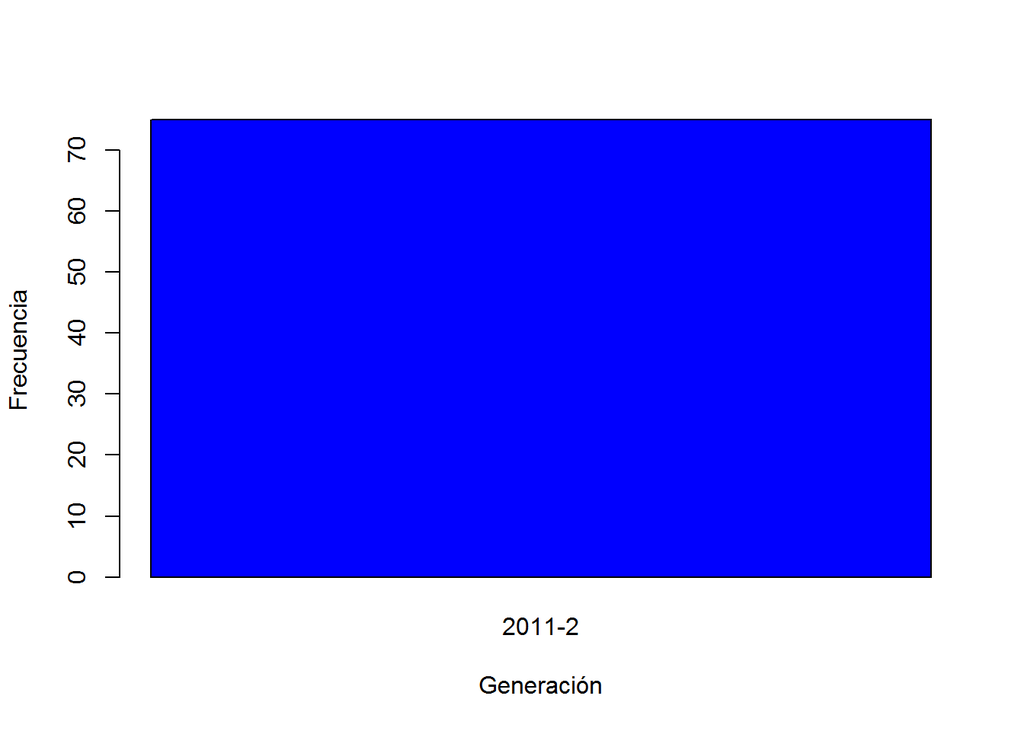

#### Plan 5123. Doctorado en Economía

```
SELECT plan, ingreso_plan, cuenta
FROM (plan_est inner join posgrado
ON plan_est.plan=posgrado.plan)
WHERE (plan_est.plan='5123'
;
```

La consulta se guarda como plan5040.csv

```
cat plan5123.csv | cut -d$'\t' -f2 | |  sort | uniq -c
```

```
##   Generación Frecuencia
## 1     2012-1         50
## 2     2012-2         36
## 3     2013-1          3
## 4     2013-2         34
## 5     2014-1          1
## 6     2014-2         35
```

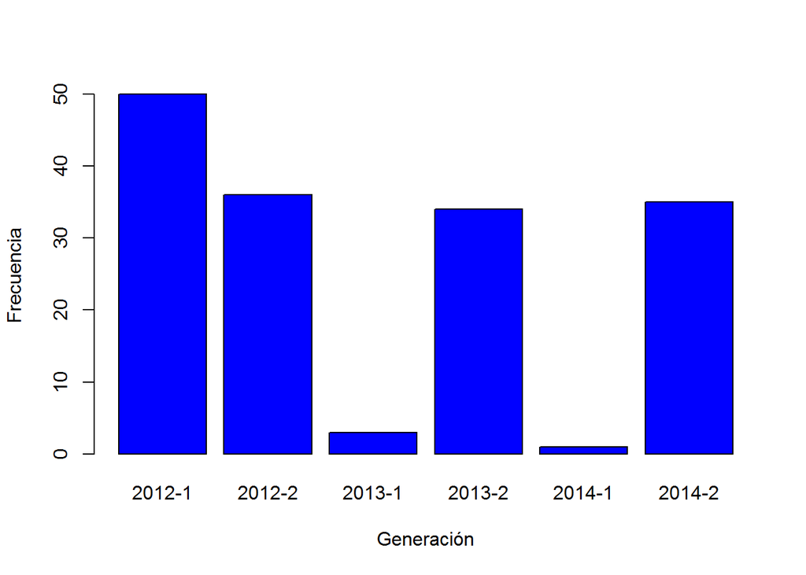

## Número de alumnos titulados por año y por mes

```
SELECT fecha_grado
FROM posgrado
;
```

La consulta se guarda como fecha_egreso.txt

```
##   Var1 Freq
## 1 2006    5
## 2 2007   23
## 3 2008   72
## 4 2009  201
## 5 2010  103
## 6 2011  180
## 7 2012  133
## 8 2013  164
## 9 2014  137
```

```
##            Var1 Freq
## 1       01enero  101
## 2     02febrero   83
## 3       03marzo   54
## 4       04abril   45
## 5        05mayo   50
## 6       06junio  114
## 7       07julio   42
## 8      08agosto   74
## 9  09septiembre   81
## 10    10octubre  105
## 11  11noviembre  165
## 12  12diciembre  104
```

## Número de alumnos titulados por programa

```
SELECT plan, nom_plan, fecha_grado
FROM (plan_est inner join posgrado
ON plan_est.plan=posgrado.plan)
;
```

La consulta se guarda como plan_grado.csv

**Maestría**

```
cat plan_grado.txt | sort | uniq -c | awk  '{if ($2=="maestria") print $1,$2,$3;}'
```

```
##   Plan Frecuencia
## 1 4040        471
## 2 4100        166
```

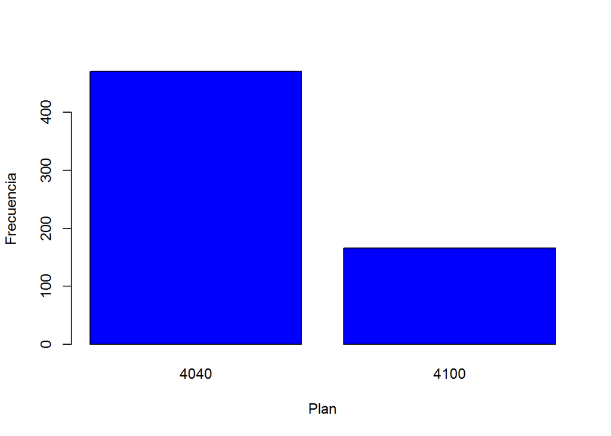

**Doctorado**

```
cat plan_grado.txt | sort | uniq -c | awk  '{if ($2=="maestria") print $1,$2,$3;}'
```

```
##   Plan Frecuencia
## 1  581          2
## 2 5040        347
## 3 5100         32
```

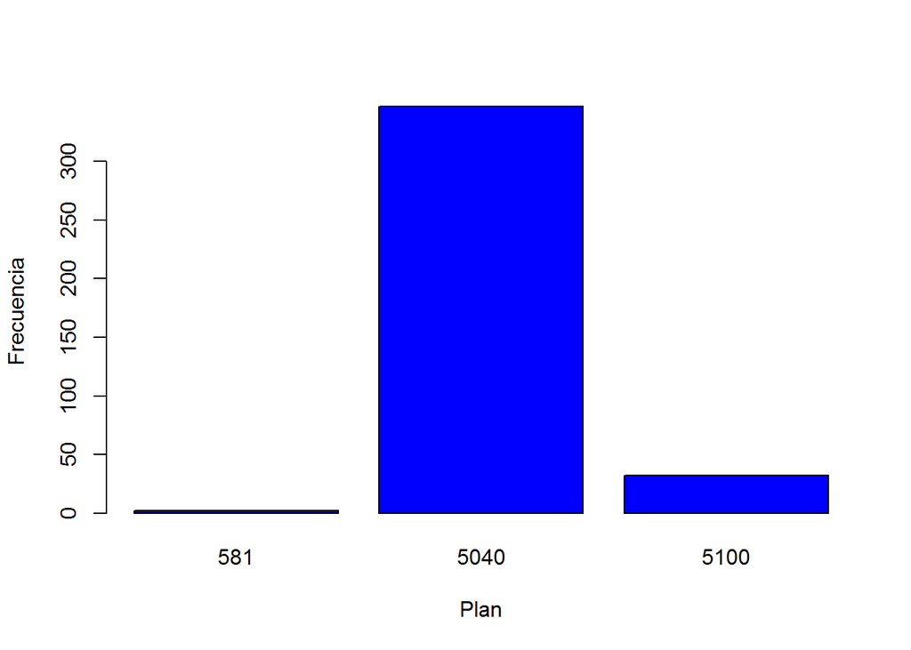

## Egreso curricular del programa de Maestría

### Plan 461. Maestría en Economía

```
SELECT plan, nom_plan, ingreso, egreso,
        (if(nom_plan=maestria, egreso-ingreso)) AS anios
FROM (plan_est inner join posgrado
ON plan_est.plan=posgrado.plan)
WHERE (plan_est.plan='461'
;
```

La consulta se guarda como plane461.csv

```
cat plane461.csv | cut -d$'\t' -f5 | |  sort | uniq -c

Los dos alumnos del plan 461 correspondientes al plan son bajas.
```

### Plan 462. Maestría en Economía

```
SELECT plan, nom_plan, ingreso, egreso,
        (if(nom_plan=maestria, egreso-ingreso)) AS anios
FROM (plan_est inner join posgrado
ON plan_est.plan=posgrado.plan)
WHERE (plan_est.plan='462'
;
```

La consulta se guarda como plane466.csv

```
cat plane462.csv | cut -d$'\t' -f5 | |  sort | uniq -c
```

```
##   Años Alumnos
## 1    0       1
## 2    2       2
```

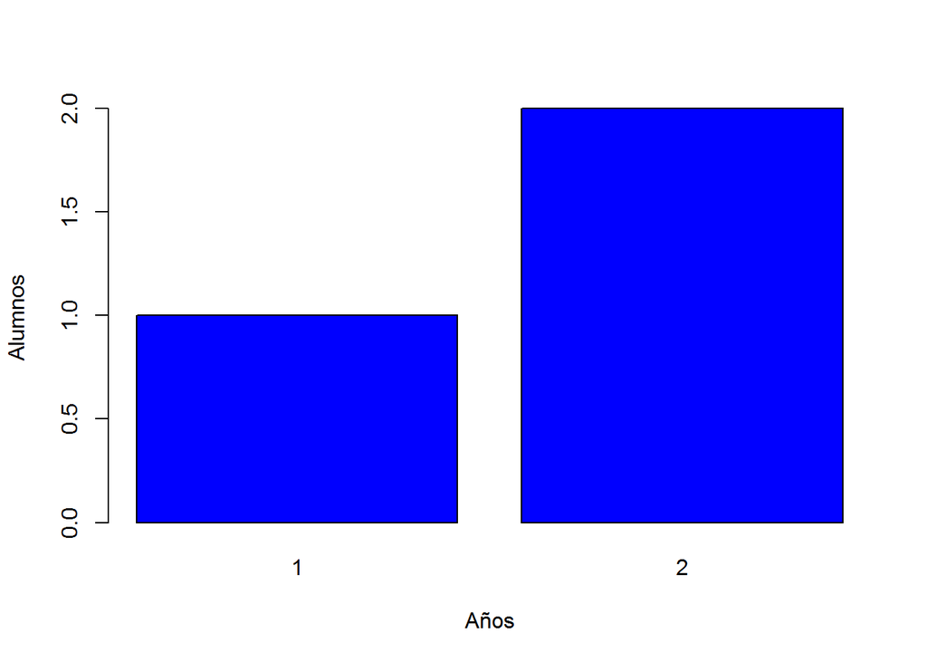

### Plan 4040. Maestría en Economía

```
SELECT plan, nom_plan, ingreso, egreso,
        (if(nom_plan=maestria, egreso-ingreso)) AS anios
FROM (plan_est inner join posgrado
ON plan_est.plan=posgrado.plan)
WHERE (plan_est.plan='4040'
;
```

La consulta se guarda como plane4040.csv

```
cat plane4040.csv | cut -d$'\t' -f5 | |  sort | uniq -c
```

```
##   Años Alumnos
## 1    0      62
## 2    2     181
## 3    3     609
## 4    4      41
## 5    5      10
## 6    6       6
## 7    8       5
```

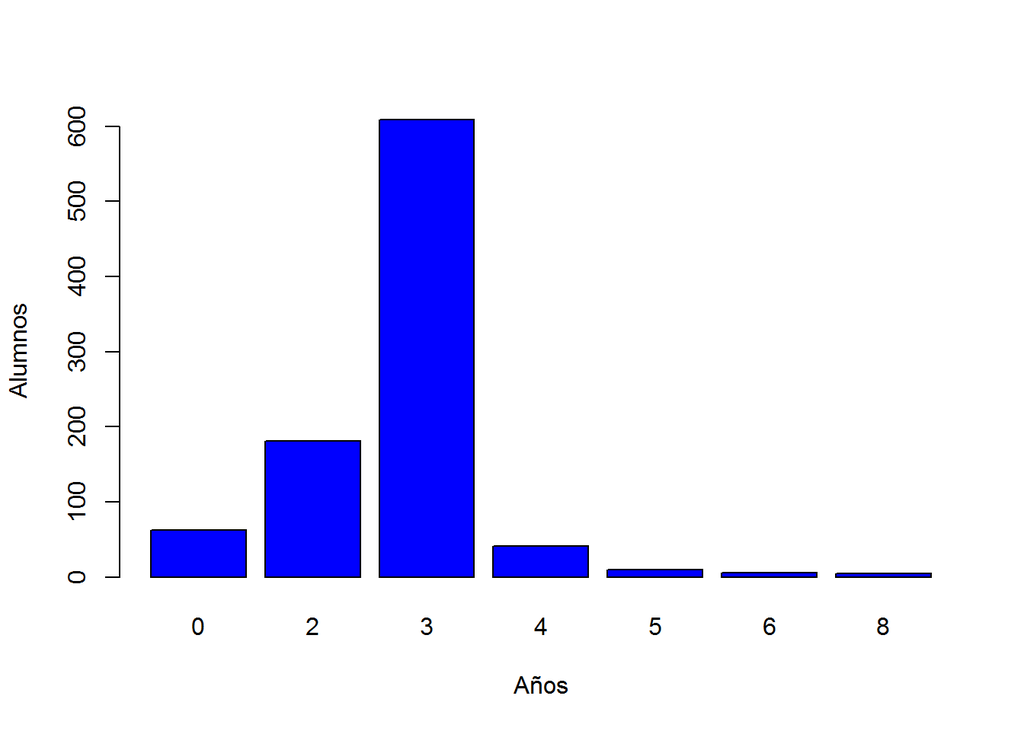

### Plan 4100. Maestría en Economía

```
SELECT plan, nom_plan, ingreso, egreso,
        (if(nom_plan=maestria, egreso-ingreso)) AS anios
FROM (plan_est inner join posgrado
ON plan_est.plan=posgrado.plan)
WHERE (plan_est.plan='4100'
;
```

La consulta se guarda como plane4100.csv

```
cat plane4100.csv | cut -d$'\t' -f5 | |  sort | uniq -c
```

```
##   Años Alumnos
## 1    0      92
## 2    2     242
## 3    3     312
## 4    4      11
```

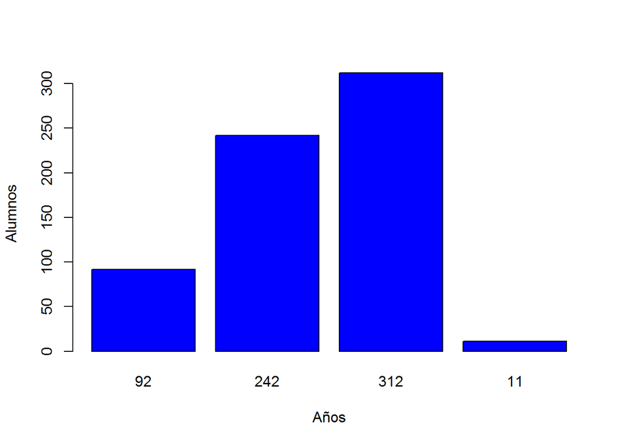